# Neural Posterior Estimation

```python
surrogate_targets = sample(
    {
        "vmax_2b": Normal(0.5, 0.1),
    },
    n=1000,
).clip(lower=0)

ax = sns.kdeplot(surrogate_targets, fill=True)
ax.set_title("Prior")
```

surrogate_targets = sample( { "vmax_2b": Normal(0.5, 0.1), }, n=1000, ).clip(lower=0) ax = sns.kdeplot(surrogate_targets, fill=True) ax.set_title("Prior")

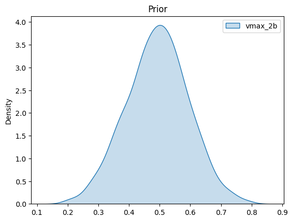

```python
ss_concs, ss_fluxes = scan.steady_state(
    model,
    to_scan=surrogate_targets,
)
```

ss_concs, ss_fluxes = scan.steady_state( model, to_scan=surrogate_targets, )

```python
fig, (ax1, ax2) = plt.subplots(1, 2, figsize=(12, 4))
_, ax = plot.violins(ss_concs, ax=ax1)
ax.set_ylabel("Concentration / a.u.")
_, ax = plot.violins(ss_fluxes, ax=ax2)
ax.set_ylabel("Flux / a.u.")
```

fig, (ax1, ax2) = plt.subplots(1, 2, figsize=(12, 4)) _, ax = plot.violins(ss_concs, ax=ax1) ax.set_ylabel("Concentration / a.u.") _, ax = plot.violins(ss_fluxes, ax=ax2) ax.set_ylabel("Flux / a.u.")

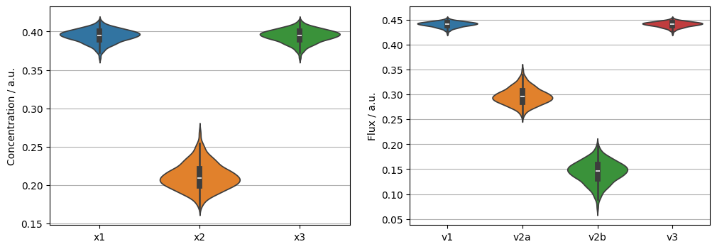

```python
surrogate_features = get_label_distribution_at_time(
    model=model,
    label_variables=label_variables,
    label_maps=label_maps,
    time=5,
    ss_concs=ss_concs,
    ss_fluxes=ss_fluxes,
    initial_labels={"x1": 0},
)
_, ax = plot.violins(surrogate_features)
ax.set_ylabel("Relative label distribution")
```

surrogate_features = get_label_distribution_at_time( model=model, label_variables=label_variables, label_maps=label_maps, time=5, ss_concs=ss_concs, ss_fluxes=ss_fluxes, initial_labels={"x1": 0}, ) _, ax = plot.violins(surrogate_features) ax.set_ylabel("Relative label distribution")

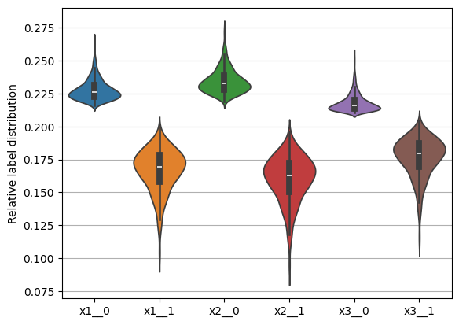

```python
estimator, losses = npe.torch.train_steady_state(
    features=surrogate_features,
    targets=surrogate_targets,
    batch_size=100,
    epochs=250,
)

ax = losses.plot()
ax.set_ylim(0, None)
```

estimator, losses = npe.torch.train_steady_state( features=surrogate_features, targets=surrogate_targets, batch_size=100, epochs=250, ) ax = losses.plot() ax.set_ylim(0, None)

```
(0.0, 0.5098537609615595)
```

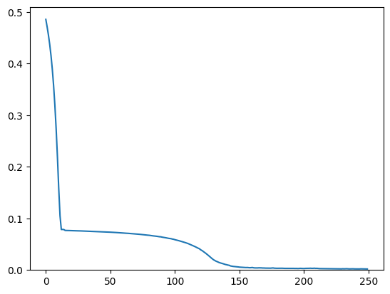

```python
fig, (ax1, ax2) = plt.subplots(
    1,
    2,
    figsize=(8, 3),
    layout="constrained",
    sharex=True,
    sharey=False,
)

ax = sns.kdeplot(surrogate_targets, fill=True, ax=ax1)
ax.set_title("Prior")

posterior = estimator.predict(surrogate_features)

ax = sns.kdeplot(posterior, fill=True, ax=ax2)
ax.set_title("Posterior")
ax2.set_ylim(*ax1.get_ylim())
plt.show()
```

fig, (ax1, ax2) = plt.subplots( 1, 2, figsize=(8, 3), layout="constrained", sharex=True, sharey=False, ) ax = sns.kdeplot(surrogate_targets, fill=True, ax=ax1) ax.set_title("Prior") posterior = estimator.predict(surrogate_features) ax = sns.kdeplot(posterior, fill=True, ax=ax2) ax.set_title("Posterior") ax2.set_ylim(*ax1.get_ylim()) plt.show()

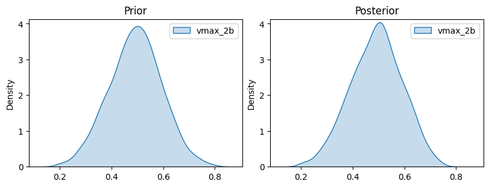

### Inverse parameter sensitivity

```python
_ = plot.heatmap(inverse_parameter_elasticity(estimator, surrogate_features.iloc[0]))
```

_ = plot.heatmap(inverse_parameter_elasticity(estimator, surrogate_features.iloc[0]))

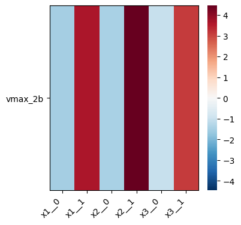

```python
elasticities = pd.DataFrame(
    {
        k: inverse_parameter_elasticity(estimator, i).loc["vmax_2b"]
        for k, i in surrogate_features.iterrows()
    }
).T

_ = plot.violins(elasticities)
```

elasticities = pd.DataFrame( { k: inverse_parameter_elasticity(estimator, i).loc["vmax_2b"] for k, i in surrogate_features.iterrows() } ).T _ = plot.violins(elasticities)

[figure not shown]